# Data Science With an Eye Towards Sustainability A12: Evaluating Statistical Models

Ian Lum

# 1 Data Context

Bike sharing is becoming a more popular means of transportation in many cities. The dataset we will analyze in this assignment comes from Capital Bikeshare, the bike-sharing service for the Washington DC area. The dataset originally comes from the [UCI Machine Learning Repository](https://archive.ics.uci.edu/ml/datasets/Bike+Sharing+Dataset). We load it here:

```r
bikes<-read_csv("http://faculty.olin.edu/dshuman/DS/bike_share.csv")
bikes$day_of_week<-factor(bikes$day_of_week,levels=c("Sat","Sun","Mon","Tue","Wed","Thu","Fri"))
bikes$year<-factor(bikes$year)
bikes<-bikes%>%
  mutate(isHot=ifelse(temp_feel>=90,"yes","no"))%>%
  mutate(day_of_year=lubridate::yday(date))
```

**Our research goal** is to understand what factors are related to total number of riders on a given day so that you can help Capital Bikeshare plan its services.

**Codebook**

The variables and their meanings are listed below:

- **`date`** : Date in format YYYY-MM-DD
- **`season`** : Season (winter, spring, summer, or fall)
- **`year`** : 2011 or 2012
- **`month`** : 3-letter month abbreviation
- **`day_of_week`** : 3-letter abbreviation for day of week
- **`weekend`**: TRUE if the case is a weekend, FALSE if the case is a weekday
- **`holiday`** : Is the day a holiday? (yes or no)
- **`temp_actual`** : Actual temperature in degrees Fahrenheit
- **`temp_feel`** : What the temperature feels like in degrees Fahrenheit
- **`humidity`** : Fraction from 0 to 1 giving the humidity level
- **`windspeed`** : Wind speed in miles per hour
- **`weather_cat`** : Weather category. 3 possible values (categ1, categ2, categ3)
  - **`categ1`**: Clear, Few clouds, Partly cloudy, Partly cloudy
  - **`categ2`**: Mist + Cloudy, Mist + Broken clouds, Mist + Few clouds, Mist
  - **`categ3`**: Light Snow, Light Rain + Thunderstorm + Scattered clouds, Light Rain + Scattered clouds
- **`riders_casual`**: Count of daily rides by casual users (non-registered users)
- **`riders_registered`**: Count of daily rides by registered users
- **`riders_total`** : Count of total daily rides (riders_casual + riders_registered)

# 2 Controlling for Covariates

Let’s explore the relationship between day of the week and number of *registered* riders.

**Exercise 2.1**

1. Before looking at any data, write down a guess for the ranking of days, from busiest to least busy in terms of registered riders.
2. Make a visualization to explore this relationship. How accurate was your guess?
3. Fit the model `riders_registered` ~ 1 + `day_of_week`, and interpret all model coefficients.
4. How does the expected number of registered riders on Monday compare to that on other weekdays? Any guesses why?

*Solution*.

1. tue, wed, mon, thur, fri, sun, sat
2. intercept: average number of registered riders on Saturday, day_of_weekWDAY: how many more/less registered riders there are on WDAY compared to Saturday
3. ~350 lower, people are lazy on mondays?

```r
bikes %>%
  group_by(day_of_week) %>%
  summarise(total=sum(riders_registered)) %>%
  arrange(desc(total))
```

```
## # A tibble: 7 × 2
##   day_of_week  total
##   <fct>        <dbl>
## 1 Thu         423935
## 2 Wed         415729
## 3 Tue         411266
## 4 Fri         409552
## 5 Mon         384719
## 6 Sat         323955
## 7 Sun         303506
```

```r
lm(riders_registered ~ 1 + day_of_week, data=bikes)
```

```
##
## Call:
## lm(formula = riders_registered ~ 1 + day_of_week, data = bikes)
##
## Coefficients:
##    (Intercept)  day_of_weekSun  day_of_weekMon  day_of_weekTue  day_of_weekWed
##         3085.3          -194.8           578.7           869.2           912.1
## day_of_weekThu  day_of_weekFri
##          991.0           852.7
```

When exploring the relationship between response $y$ and predictor $x$, there are typically covariates for which we want to control.

**Exercise 2.2**

1. Control for holidays by fitting the model `riders_registered` ~ 1 + `day_of_week` + `holiday`.
2. How did each of the coefficients for `day_of_week` change from your original model? Can you explain why?
3. Make a side-by-side boxplot with `day_of_week` on the x-axis and two box plots for each day: one for holidays and one for non-holidays. Relate this graphic back to the changes you saw in the model coefficients.
4. What other variables might we want to control for when examining the relationship between `riders_registered` and `day_of_week`?

```r
lm(riders_registered ~ 1 + day_of_week + holiday, data=bikes)
```

```
##
## Call:
## lm(formula = riders_registered ~ 1 + day_of_week + holiday, data = bikes)
##
## Coefficients:
##    (Intercept)  day_of_weekSun  day_of_weekMon  day_of_weekTue  day_of_weekWed
##         3085.3          -194.8           752.8           880.9           923.8
## day_of_weekThu  day_of_weekFri      holidayyes
##         1014.4           876.2         -1218.7
```

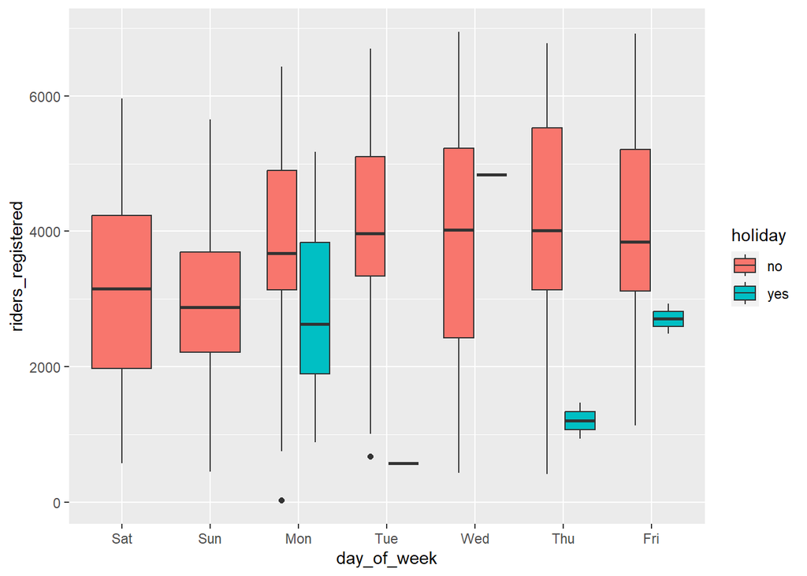

```r
ggplot(bikes, aes(x=day_of_week, y=riders_registered, fill=holiday))+
  geom_boxplot()
```

# 3 Model Evaluation

One of the most famous quotes in statistics is the following from George Box (1919–2013):

> “All models are wrong, but some are useful.”

Thus far, we’ve constructed models from sample data and used these to tell stories about the relationships among variables of interest. We haven’t yet discussed the *quality* of these models. To this end, it’s important to ask the following.

> **Model evaluation questions**
> - How **fair** is our model? Are our model building process and application ethical? Biased? What are the societal impacts of this analysis?
> - How **strong** is our model? How well does it explain the variability in the response?
> - How **wrong** is our model? Are our model assumptions reasonable?
> - How **accurate** are our model’s predictions?

Though these questions are broadly applicable across all machine learning techniques, we’ll examine these questions in the linear regression context. Let $y$ be a response variable with a set of $k$ predictors $(x_{1}, x_{2}, ..., x_{k})$. Then the population linear regression model is

$$y = \beta_0 + \beta_1 x_{1} + \beta_2 x_{2} + \cdots + \beta_k x_{k} + \varepsilon$$

where

- $\beta_0 + \beta_1 x_{1} + \beta_2 x_{2} + \cdots + \beta_k x_{k}$ captures the trend of the relationship
- $\epsilon$ reflects individual deviation from the trend (residual)

## 3.1 How FAIR is our model?

It’s critical to ask whether our model is *fair*:

- Who collected the data / who funded the data collection?
- How did they collect the data?
- Why did they collect the data?
- What are the implications of the analysis on individuals and society?

Examples of *unfair* models (or “algorithms”) unfortunately abound:

- [Amazon’s resume filter discriminated against women applicants](https://www.bbc.com/news/technology-45809919)
- [Facial recognition models, increasingly being used in police surveillance, are more likely to misidentify non-white subjects](https://www.nytimes.com/2019/07/08/us/detroit-facial-recognition-cameras.html)
- [ICEs algorithm disproportionately recommended detention](https://slate.com/technology/2020/03/ice-lawsuit-hijacked-algorithm.html)

## 3.2 How STRONG is our model?

Building models is about **explaining variation**. It turns out that we can measure **how good a model is** (model quality) by measuring **how much variation it explains**.

### 3.2.1 Partitioning variability

Consider the model `riders_total ~ 1 + temp_feel`:

```r
modA<-lm(data=bikes,riders_total~1+temp_feel)
```

The variance of the fitted values and the variance of the residuals sum to the variance of the observed response values:

$$\text{Var(fitted) + Var(residuals) = Var(response)}$$

```r
(varFitted<-var(modA$fitted.values))
```

```
## [1] 1494525
```

```r
(varResid<-var(resid(modA)))
```

```
## [1] 2258263
```

```r
varFitted+varResid
```

```
## [1] 3752788
```

```r
var(bikes$riders_total)
```

```
## [1] 3752788
```

This is in fact always true for linear regression models!

Further, the better the model, the greater Var(fitted). Putting this together, the $R^2$ measure of model quality compares Var(fitted) to Var(response):

$$R^2 = \frac{\text{variance of fitted values}}{\text{variance of observed response values}}$$

> **More About $R^2$ (“Multiple R-Squared”)**
> - $0 \leq R^2 \leq 1$
> - We can interpret $R^2$ as the *proportion of the variability in the observed response values that’s explained by the model* (variance of fitted values). Thus $1 - R^2$ is the *proportion of the variability in the observed response values that’s left UNexplained by the model*
> - Good models “explain away” lots of variation in the response. With a good model, the amount of response variation that is UNexplained should be low - good models explain why responses are different (vary)
> - High $R^2$ means that the model explained a lot (high variance of fitted values) and that the model left little UNexplained (low variance of residuals)
> - Thus, the closer $R^2$ is to 1, the better the model. However, below we will discuss caveats when we look at models with many predictors

### 3.2.2 Relationship to correlation coefficient

If there is just a single quantitative explanatory variable, then $R^2$ is equal to the square of the correlation coefficient, $R$.

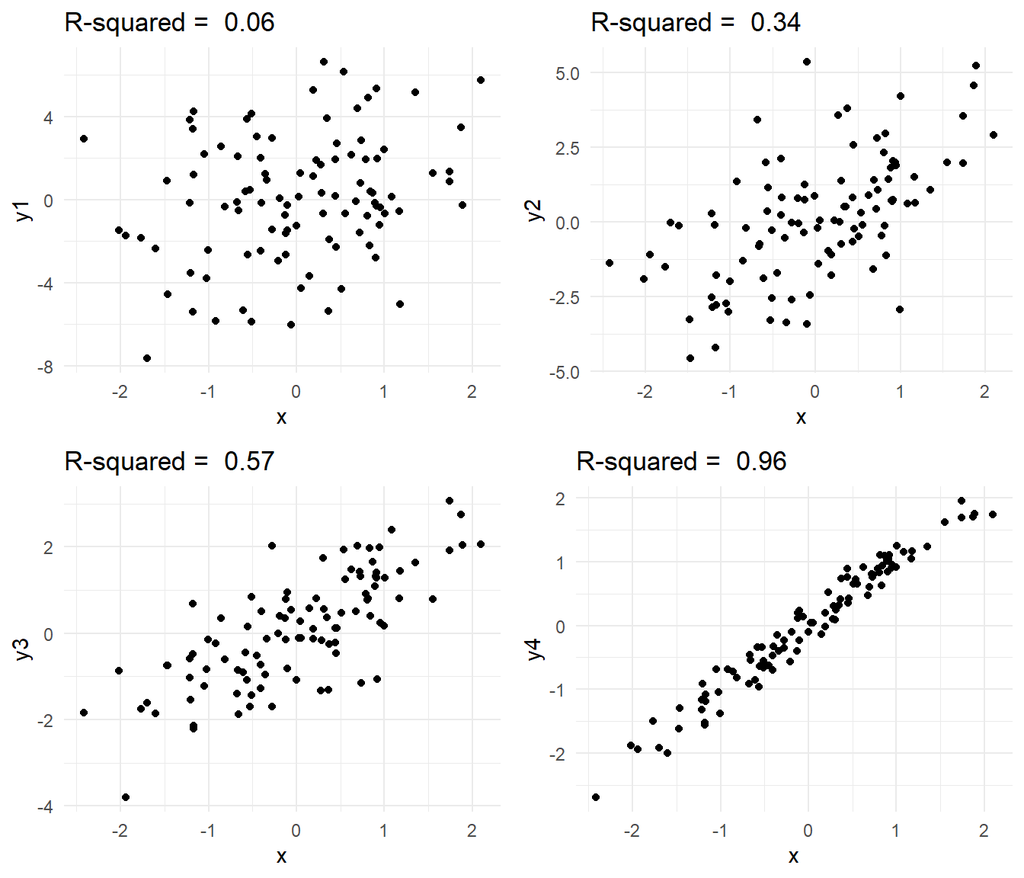

### 3.2.3 Nested models and adjusted $R^2$

So, in our explorations of multivariate models, we’ve discussed how:

- adding more predictors to a model might help us better explain the response;
- adding more predictors to a model lets us control for important covariates;
- adding more predictors to a model impacts our interpretation of the model coefficients.

There are also limitations to indiscriminately adding more predictors to our model!

Consider the following series of **nested models**:

**Model A:** `riders_total` ~ 1 + `temp_feel`

**Model B:** `riders_total` ~ 1 + `temp_feel` + `season`

**Model C:** `riders_total` ~ 1 + `temp_feel` + `season` + `season:temp_feel`

**Model D:** `riders_total` ~ 1 + `temp_feel` + `season` + `season:temp_feel` + `weekend`

**Model E:** `riders_total` ~ 1 + `temp_feel` + `season` + `season:temp_feel` + `weekend` + `windspeed`

How much of the variation in `riders_total` does each of the five models explain? Let’s check the multiple $R^2$ coefficients. To find each one, we use the `summary` command:

```r
modA<-lm(data=bikes,riders_total~1+temp_feel)
summary(modA)
```

```
##
## Call:
## lm(formula = riders_total ~ 1 + temp_feel, data = bikes)
##
## Residuals:
##     Min      1Q  Median      3Q     Max
## -4598.7 -1091.6   -91.8  1072.0  4383.7
##
## Coefficients:
##              Estimate Std. Error t value Pr(>|t|)
## (Intercept) -1721.495    288.851   -5.96 3.93e-09 ***
## temp_feel      83.354      3.795   21.96  < 2e-16 ***
## ---
## Signif. codes:  0 '***' 0.001 '**' 0.01 '*' 0.05 '.' 0.1 ' ' 1
##
## Residual standard error: 1504 on 729 degrees of freedom
## Multiple R-squared:  0.3982, Adjusted R-squared:  0.3974
## F-statistic: 482.5 on 1 and 729 DF,  p-value: < 2.2e-16
```

Here is a table of $R^2$ values:

|  | $R^2$ |
| --- | --- |
| Model A | 0.3982 |
| Model B | 0.4545 |
| Model C | 0.4841 |
| Model D | 0.4842 |
| Model E | 0.4927 |

**Exercise 3.1** Based on these $R^2$ values, which variables might you decide to include in your model?

- As expected, the more variables we add, the more variation we can explain (it is mathematically guaranteed that the $R^2$ cannot decrease for a nested model like this)
- Many statisticians argue that $R^2$ is therefore not a good measure of fit for a model
- An alternative is the adjusted $R^2$ measure:

$$\overline{R^2} = R^2-(1-R^2)*\frac{p}{n-p-1},$$

where $n$ is the number of cases in the data frame, and $p$ is the number of explanatory variables (not including the intercept)

- $\overline{R^2}$ is never bigger than $R^2$, and can be negative
- Slightly different interpretation than $R^2$: rather than using it as a measure of fit for the model (how $R^2$ is used), it is more commonly used as a comparative tool when evaluating different nested models (i.e., when trying to decide whether to add another explanatory variable to the model)

Let’s append our table with the adjusted $R^2$ values (also found by `summary`):

|  | $R^2$ | Adj. $R^2$ |
| --- | --- | --- |
| Model A | 0.3982 | 0.3974 |
| Model B | 0.4545 | 0.4515 |
| Model C | 0.4841 | 0.4791 |
| Model D | 0.4842 | 0.4785 |
| Model E | 0.4927 | 0.4864 |

The fact that the adjusted $R^2$ goes down from Model C to Model D suggests that we might not need to include the `weekend` variable in our model. Excluding it yields the following model:

```r
modF<-lm(data=bikes,riders_total~1+temp_feel+season+temp_feel:season+windspeed)
summary(modF)
```

```
##
## Call:
## lm(formula = riders_total ~ 1 + temp_feel + season + temp_feel:season +
##     windspeed, data = bikes)
##
## Residuals:
##     Min      1Q  Median      3Q     Max
## -4430.2 -1044.7  -158.1  1214.4  3137.8
##
## Coefficients:
##                         Estimate Std. Error t value Pr(>|t|)
## (Intercept)             -400.149    866.031  -0.462 0.644185
## temp_feel                 79.853     12.156   6.569 9.70e-11 ***
## seasonspring            -598.629   1193.785  -0.501 0.616204
## seasonsummer            8091.897   1660.850   4.872 1.36e-06 ***
## seasonwinter           -2556.682   1092.967  -2.339 0.019596 *
## windspeed                -35.869     10.292  -3.485 0.000522 ***
## temp_feel:seasonspring     2.354     16.080   0.146 0.883638
## temp_feel:seasonsummer   -97.801     19.801  -4.939 9.75e-07 ***
## temp_feel:seasonwinter    23.627     16.798   1.406 0.160009
## ---
## Signif. codes:  0 '***' 0.001 '**' 0.01 '*' 0.05 '.' 0.1 ' ' 1
##
## Residual standard error: 1387 on 722 degrees of freedom
## Multiple R-squared:  0.4927, Adjusted R-squared:  0.487
## F-statistic: 87.64 on 8 and 722 DF,  p-value: < 2.2e-16
```

### 3.2.4 Redundancy

Let’s add a new column to the data set that has the perceived temperature in Celcius instead of Farenheit:

```r
bikes<-bikes%>%
  mutate(temp_feel_c=(temp_feel-32)*5/9)
```

Here is the `riders_total` data plotted against temperatures in both scales:

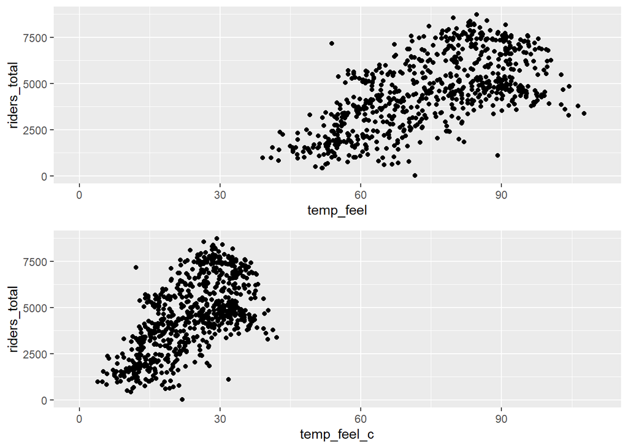

**Exercise 3.2**

1. Discuss with your group which of the following three models will yield the highest $R^2$ level:

**Model 1:** `riders_total` ~ 1 + `temp_feel`

**Model 2:** `riders_total` ~ 1 + `temp_feel_c`

**Model 3:** `riders_total` ~ 1 + `temp_feel` + `temp_feel_c`

b. Try it out in `R`. How do the $R^2$ values compare?  
c. Interpret the model coefficients for each model, and explain what is going on with these models.

```r
summary(lm(riders_total ~ 1 + temp_feel, data=bikes))
```

```
##
## Call:
## lm(formula = riders_total ~ 1 + temp_feel, data = bikes)
##
## Residuals:
##     Min      1Q  Median      3Q     Max
## -4598.7 -1091.6   -91.8  1072.0  4383.7
##
## Coefficients:
##              Estimate Std. Error t value Pr(>|t|)
## (Intercept) -1721.495    288.851   -5.96 3.93e-09 ***
## temp_feel      83.354      3.795   21.96  < 2e-16 ***
## ---
## Signif. codes:  0 '***' 0.001 '**' 0.01 '*' 0.05 '.' 0.1 ' ' 1
##
## Residual standard error: 1504 on 729 degrees of freedom
## Multiple R-squared:  0.3982, Adjusted R-squared:  0.3974
## F-statistic: 482.5 on 1 and 729 DF,  p-value: < 2.2e-16
```

```r
summary(lm(riders_total ~ 1 + temp_feel_c, data=bikes))
```

```
##
## Call:
## lm(formula = riders_total ~ 1 + temp_feel_c, data = bikes)
##
## Residuals:
##     Min      1Q  Median      3Q     Max
## -4598.7 -1091.6   -91.8  1072.0  4383.7
##
## Coefficients:
##             Estimate Std. Error t value Pr(>|t|)
## (Intercept)  945.824    171.291   5.522 4.67e-08 ***
## temp_feel_c  150.037      6.831  21.965  < 2e-16 ***
## ---
## Signif. codes:  0 '***' 0.001 '**' 0.01 '*' 0.05 '.' 0.1 ' ' 1
##
## Residual standard error: 1504 on 729 degrees of freedom
## Multiple R-squared:  0.3982, Adjusted R-squared:  0.3974
## F-statistic: 482.5 on 1 and 729 DF,  p-value: < 2.2e-16
```

```r
summary(lm(riders_total ~ 1 + temp_feel + temp_feel_c, data=bikes))
```

```
##
## Call:
## lm(formula = riders_total ~ 1 + temp_feel + temp_feel_c, data = bikes)
##
## Residuals:
##     Min      1Q  Median      3Q     Max
## -4598.7 -1091.6   -91.8  1072.0  4383.7
##
## Coefficients: (1 not defined because of singularities)
##              Estimate Std. Error t value Pr(>|t|)
## (Intercept) -1721.495    288.851   -5.96 3.93e-09 ***
## temp_feel      83.354      3.795   21.96  < 2e-16 ***
## temp_feel_c        NA         NA      NA       NA
## ---
## Signif. codes:  0 '***' 0.001 '**' 0.01 '*' 0.05 '.' 0.1 ' ' 1
##
## Residual standard error: 1504 on 729 degrees of freedom
## Multiple R-squared:  0.3982, Adjusted R-squared:  0.3974
## F-statistic: 482.5 on 1 and 729 DF,  p-value: < 2.2e-16
```

*Solution*.

2. the R^2 is all the same
3. they scale based on C vs F ``

### 3.2.5 Multicollinearity

Consider the following three models:

```r
model_temp_a <- lm(riders_total ~ temp_actual, data = bikes)
model_temp_a$coefficients
```

```
## (Intercept) temp_actual
## -1664.79853    89.98252
```

```r
model_temp_f <- lm(riders_total ~ temp_feel, data = bikes)
model_temp_f$coefficients
```

```
## (Intercept)   temp_feel
## -1721.49476    83.35371
```

```r
model_temp_af <- lm(riders_total ~ temp_actual + temp_feel, data = bikes)
model_temp_af$coefficients
```

```
## (Intercept) temp_actual   temp_feel
## -1726.29751    14.44732    70.15687
```

**Exercise 3.3**

1. Brainstorm with your group why the coefficients for `temp_feel` and `temp_actual` in `model_temp_af` change so much from the single predictor models `model_temp_a` and `model_temp_f`.
2. Which model(s) (of the 3 above) provide interpretable coefficients / information?

## 3.3 How WRONG is our model?

The next question we want to ask is: Does our model meet the model assumptions?

Examine the relationship between `temp_feel` and `riders_total`:

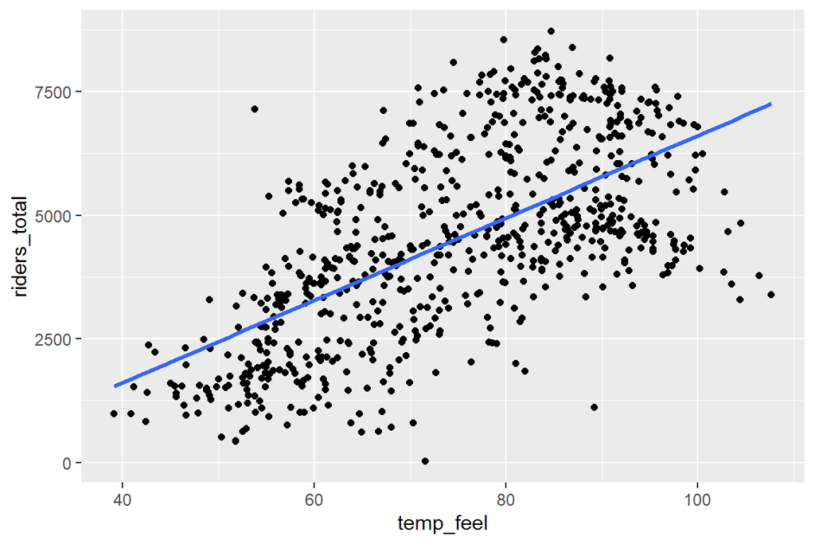

A single line may not be the correct model, as bikers may be less inclined to ride once the temperature reaches a certain level. Instead, we can try fitting a curve, such as a quadratic function.

### 3.3.1 Side note on transformation terms

When the relationship between two variables does not appear to be linear based on visualizations or known physical models, it may be appropriate to add *transformation terms* to statistical models. These may include, e.g., polynomial terms, exponential, logarithmic, ratios, and others. We discuss only polynomials here as an example.

Note the use of `poly(x,2)` for a quadratic function of the variable `x`:

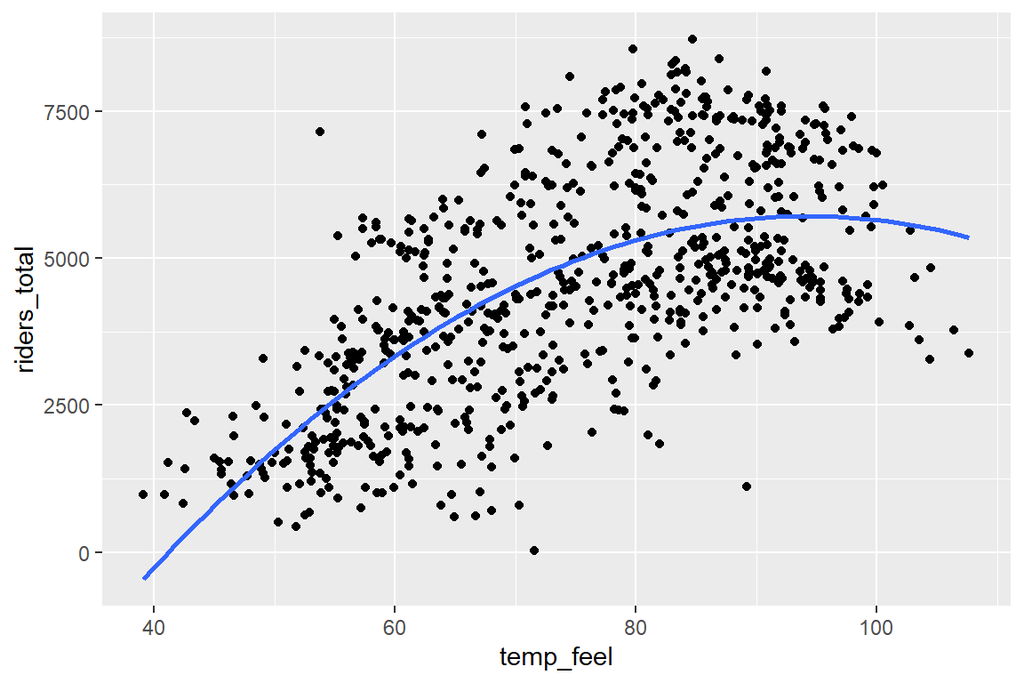

```r
ggplot(bikes,aes(x=temp_feel,y=riders_total))+
  geom_point()+
  geom_smooth(method="lm",formula=y~poly(x,2),se=FALSE)
```

```r
modPoly2<-lm(data=bikes,riders_total~poly(temp_feel,2,raw=TRUE))
modPoly2$coefficients
```

```
##                     (Intercept) poly(temp_feel, 2, raw = TRUE)1
##                   -12331.071949                      383.028164
## poly(temp_feel, 2, raw = TRUE)2
##                       -2.032154
```

The curve given by this model is

```
-12331.1+383.0*`temp_feel`-2.0*`temp_feel`^2
```

We could also try a cubic function:

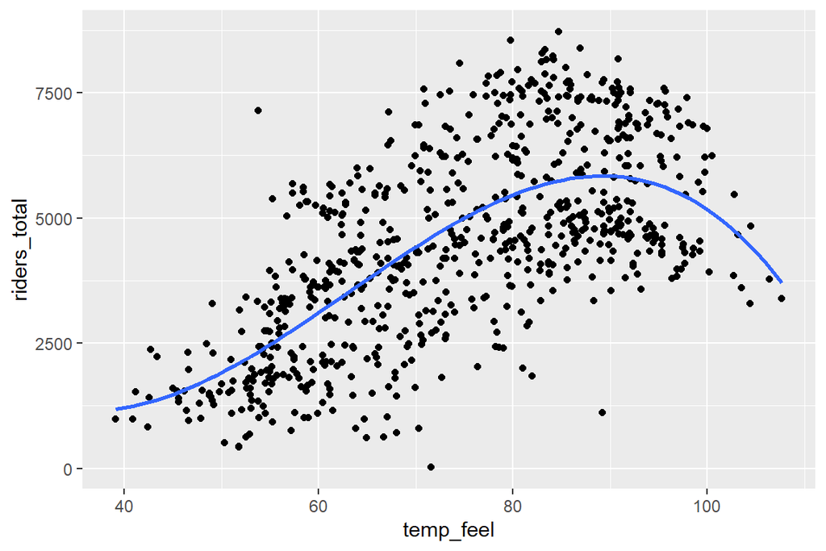

```r
ggplot(bikes,aes(x=temp_feel,y=riders_total))+
  geom_point()+
  geom_smooth(method="lm",formula=y~poly(x,3),se=FALSE)
```

**Important Warning**: Although tempting, it is rarely a good idea to include very high order polynomial terms in a statistical model like this. That is because the extra degrees of freedom often result in overfitting the model to the sample data.

Here is an example of overfitting:

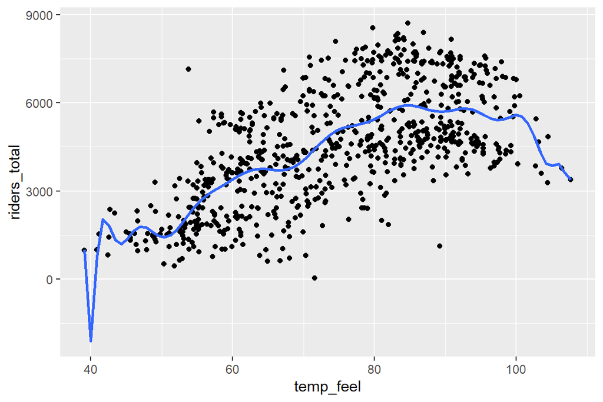

```r
ggplot(bikes,aes(x=temp_feel,y=riders_total))+
  geom_point()+
  geom_smooth(method="lm",formula=y~poly(x,20),se=FALSE)
```

**Important Note**: The models above include terms that are non-linear in the explanatory variable `temp_feel`; however, they are still *linear* models (created with `lm()`), as the model is a linear combination of the explanatory vectors.

### 3.3.2 Linear regression assumptions & residual analysis

Now let’s return to the main question of how wrong is our model. Is there a more formal method to capture our intuition that the first straight line model above does not represent the trend of the data? To answer that, we first need to review the assumptions behind linear regression models.

Recall our population linear regression model:

$$y = \beta_0 + \beta_1 x_{1} + \beta_2 x_{2} + \cdots + \beta_k x_{k} + \varepsilon.$$

In “ordinary” least squares regression, there are two key assumptions:

- **Assumption 1:**  
  The observations of ($y,x_1,x_2,...,x_k$) for any case are independent of the observations for any other case.
- **Assumption 2:**
  At any set of predictor values $(x_{1}^*, x_{2}^*, \ldots, x_{k}^*)$,
  $$\varepsilon \sim N(0,\sigma^2)$$
  That is:
  1. the expected value of the residuals is $E(\varepsilon) =0$  
     In words: Across the entire model, responses are balanced above and below the trend. Thus, the model accurately describes the “shape” and “location” of the trend.
  2. *homoskedasticity*: the variance of the residuals $Var(\varepsilon) = \sigma^2$  
     In words: Across the entire model, variability from the trend is roughly constant.
  3. the $\varepsilon$ are *normally distributed*  
     In words: individual responses are normally distributed around the trend (closer to the trend and then tapering off)

### 3.3.3 Checking the model assumptions

Let’s build some intuition for these assumptions.

**Exercise 3.4** Come up with some examples that violate Assumption 1.

*Solution*. Data of different people at different times, the same person on two rows would not be independent

**Example 3.1** For the plots below, indicate which parts of Assumption 2 hold.

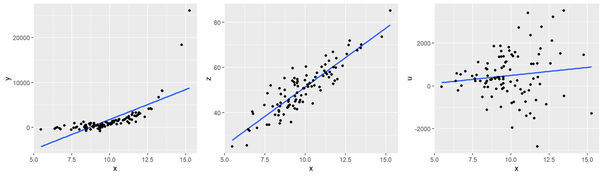

*Solution*. We quickly lose the ability to visualize a model as the number of predictors increases. Instead of checking the assumptions by eye, we can construct **residual plots**.

```r
# compute all residuals for each model
yMod<-lm(y~x,dat1)
zMod<-lm(z~x,dat1)
uMod<-lm(u~x,dat1)

dat1$yRes<-yMod$residuals
dat1$zRes<-zMod$residuals
dat1$uRes<-uMod$residuals
```

There are two key plots we want to examine:

- predicted values vs. residuals
- Q-Q plot

Here are the predicted values vs. residuals plots:

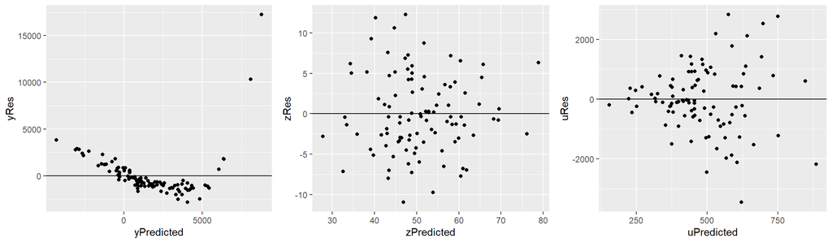

```r
dat1$yPredicted<-yMod$fitted.values
dat1$zPredicted<-zMod$fitted.values
dat1$uPredicted<-uMod$fitted.values
ggg1 <- ggplot(dat1, aes(y=yRes, x=yPredicted)) +
    geom_point() +
    geom_hline(yintercept=0)
ggg2 <- ggplot(dat1, aes(y=zRes, x=zPredicted)) +
    geom_point() +
    geom_hline(yintercept=0)
ggg3 <- ggplot(dat1, aes(y=uRes, x=uPredicted)) +
    geom_point() +
    geom_hline(yintercept=0)
grid.arrange(ggg1,ggg2,ggg3,ncol=3)
```

As for Assumption 2(a), note that for any least squares fitting, the sample mean of the residuals will be equal to 0:

```r
# compute means of residuals for each model
mean(yMod$residuals)
```

```
## [1] 3.43392e-14
```

```r
mean(zMod$residuals)
```

```
## [1] -1.539697e-16
```

```r
mean(uMod$residuals)
```

```
## [1] 2.420009e-14
```

However, the expected value of the residuals may change with the values of the predictor variables. We can see this in the first of the three predicted values vs. residuals plots. At different predicted values (corresponding to different values of the single predictor in this case), the expected value of the residuals is different. For low and high values of `yPredicted`, the model underestimates the data, while for middle values, it overestimates the data. Said more simply, the model does not capture the trend of the data! We can often fix this by transforming the predictor variables and/or the response variables. In this case, for example, we could use a model of `log(y)~x`:

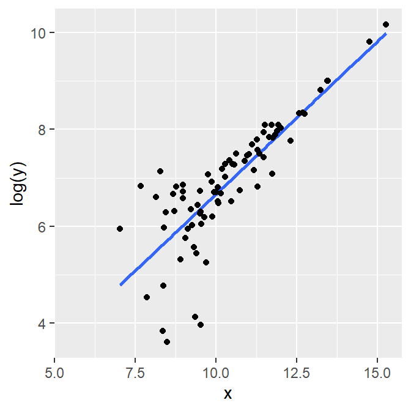

```r
ggplot(dat1, aes(x=x,y=log(y))) + geom_smooth(method="lm",se=FALSE) + geom_point()
```

Sticking with the same series of three predicted values vs. residuals plots, we see the third example ($u$) violates the homoskedasticity assumption (2b); as the predicted values increase, the variance of the residuals increases. **Generally speaking, if we see cone or banana shapes in these predicted-residual plots, one or more of the assumptions are not satisfied.**

Next, we look at [quantile-quantile (Q-Q) plots](https://en.wikipedia.org/wiki/Q%E2%80%93Q_plot):

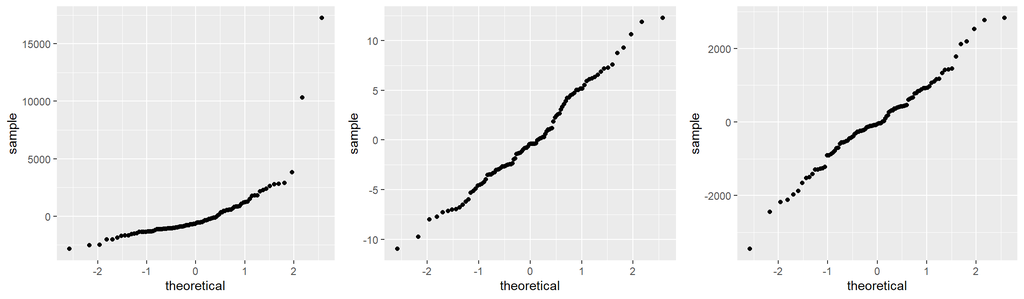

```r
hhh1 <- ggplot(dat1, aes(sample=yRes)) +
    geom_qq()
hhh2 <- ggplot(dat1, aes(sample=zRes)) +
    geom_qq()
hhh3 <- ggplot(dat1, aes(sample=uRes)) +
    geom_qq()
grid.arrange(hhh1,hhh2,hhh3,ncol=3)
```

We can also see the violation of Assumption 2c by plotting the distributions of the residuals for each model, as compared to normal distributions with mean 0 and the same standard deviation as the residuals:

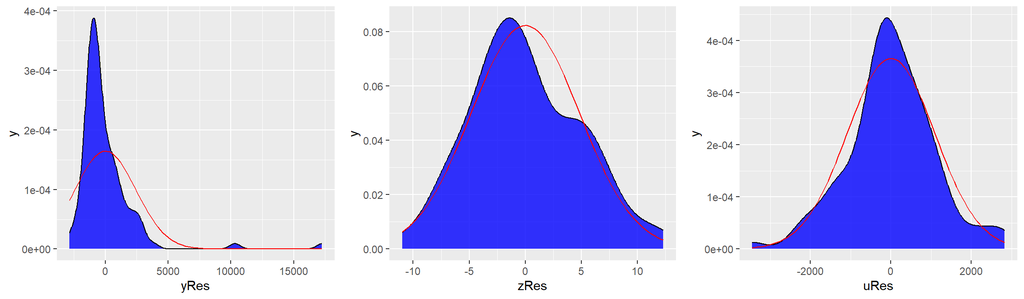

```r
# look at the distribution of residuals for each model
h1 <- ggplot(dat1, aes(x=yRes)) +
  geom_density(fill="blue",alpha=.8)+
  stat_function(fun = dnorm, n = 101, args = list(mean = 0, sd = sd(dat1$yRes)),color="red")
h2 <- ggplot(dat1, aes(x=zRes)) +
  geom_density(fill="blue",alpha=.8)+
  stat_function(fun = dnorm, n = 101, args = list(mean = 0, sd = sd(dat1$zRes)),color="red")
h3 <- ggplot(dat1, aes(x=uRes)) +
  geom_density(fill="blue",alpha=.8)+
  stat_function(fun = dnorm, n = 101, args = list(mean = 0, sd = sd(dat1$uRes)),color="red")
grid.arrange(h1,h2,h3,ncol=3)
```

### 3.3.4 Residual analysis summary

| Assumption | Consequence | Diagnostic | Solution |
| --- | --- | --- | --- |
| independence | inaccurate inference | common sense / context | use a different modeling technique / specialized methods |
| $E(\varepsilon)=0$ | lack of model fit | plot of residuals vs predictions | transform $x$ and/or $y$ |
| $Var(\varepsilon)=\sigma^2$ | inaccurate inference | plot of residuals vs predictions | transform $y$ (Box-Cox) |
| normality of $\varepsilon$ | if extreme, inaccurate inference | Q-Q plot | if extreme, transform $y$ |

## 3.4 How ACCURATE are our model’s predictions?

The model evaluation metrics we’ve examined thus far are focused on quantifying how much of the variance of the given response variable data is explained by the explanatory variables. If the intention is to use the model to make predictions of the response variable for new values of the explanatory variables, there are some additional important considerations that we won’t explore further, but are covered in Machine Learning:

- **Training** and **testing** our model using the same data can result in overly optimistic assessments of model quality. For example, **in-sample** or **training errors** (i.e., error metrics calculated using the same data that we used to train the model) are often smaller than **testing errors** (i.e., error metrics calculated using data not used to train the model).
- Adding more and more predictors to a model might result in **overfitting** the model to the noise in our sample data. In turn, the model loses the bigger picture and does not generalize to new data outside our sample (i.e., it results in bad predictions).
- A common approach to avoid overfitting is **validation**. In practice, we only have one sample of data. We need to use this one sample to both train (build) and test (evaluate) our model. Validation a simple strategy where we randomly select a portion of the sample to *train* the model and then *test* the model on rest of the sample. In **cross-validation**, a commonly used form of validation, we do this split repeatedly with different training/test sets each time. Here is an example algorithm:

> **$k$-Fold Cross Validation (CV)**
> 1. Divide the data into $k$ groups / folds of equal size
> 2. Repeat the following procedures for each fold $j \in \{1,2,...,k\}$:
>    - Divide the data into a test set (fold $j$) & training set (the other $k-1$ folds)
>    - Fit a model using the training set.
>    - Use this model to predict the responses for the $n_j$ cases in fold $j$: $\hat{y}_1, ..., \hat{y}_{n_j}$
>    - Calculate an error metric for fold $j$; for example, the mean squared error (MSE) is given by
>      $$\text{MSE}_j = \frac{1}{n_j}\sum_{i=1}^{n_j} (y_i - \hat{y}_i)^2$$
> 3. Calculate the “cross validation error”, e.g., the average MSE from the $k$ folds:
>    $$\text{CV}_{(k)} = \frac{1}{k} \sum_{j=1}^k \text{MSE}_j$$
- The `caret` (**C**lassification **A**nd **RE**gression **T**raining) package in `R` is useful for training and testing models. Here are [excellent documentation](https://topepo.github.io/caret/index.html) and a [cheat sheat](https://rstudio.github.io/cheatsheets/caret.pdf)

# 4 More Practice

**Exercise 4.1** Consider the following linear regression models:  
a. `riders_total` ~ 1+`temp_feel`  
b. `riders_total` ~ poly(`temp_feel`,3)  
c. `riders_total` ~ 1 + `temp_feel` + `season` + `temp_feel:season`  
d. `temp_feel` ~ poly(day_of_year,2)  
e. `riders_registered` ~ 1 + `day_of_week` + `holiday`  
f. `riders_registered` ~ `day_of_week` + `holiday` + `temp_feel`

For each of the six models, complete the following:  
i. Make an appropriate visualiation of the data variables involved in the model.  
ii. Make a plot of the predicted values vs. the residual values.  
iii. Make a Q-Q plot of the residuals.  
iv. Explain which of the linear regression model assumptions are met, and which are not.

For all of your plots with categorical data, it might be helpful to add color or shape aesthetics for the categorical variables.

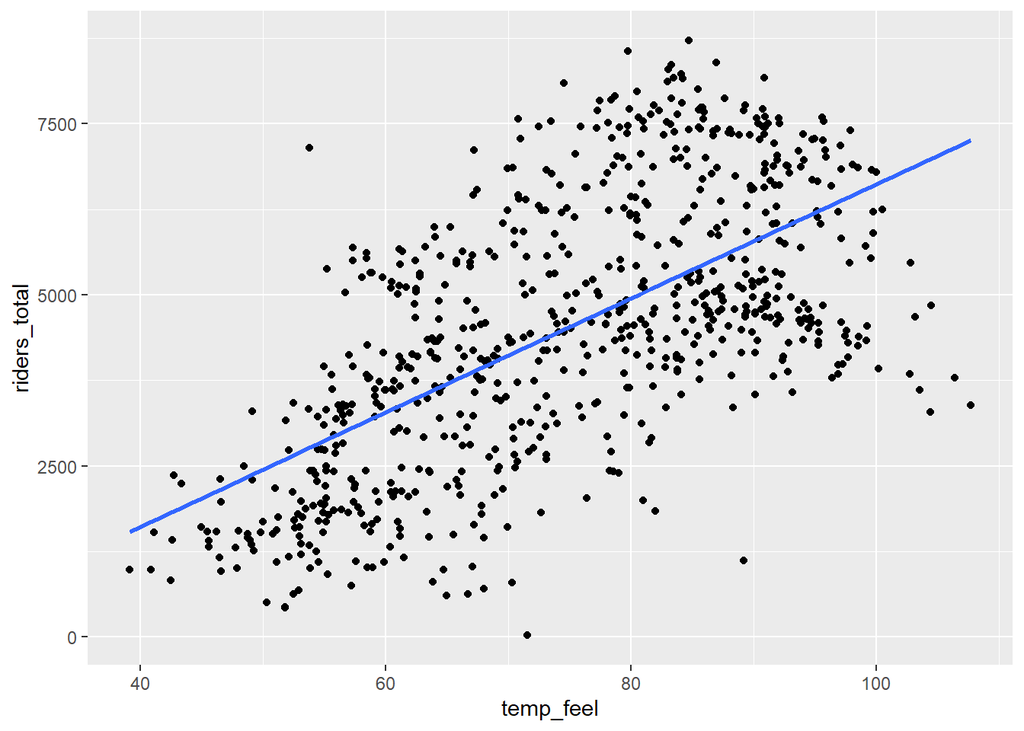

```r
ggplot(bikes, aes(x=temp_feel, y=riders_total))+
  geom_point()+
  geom_smooth(method="lm", se=FALSE)
```

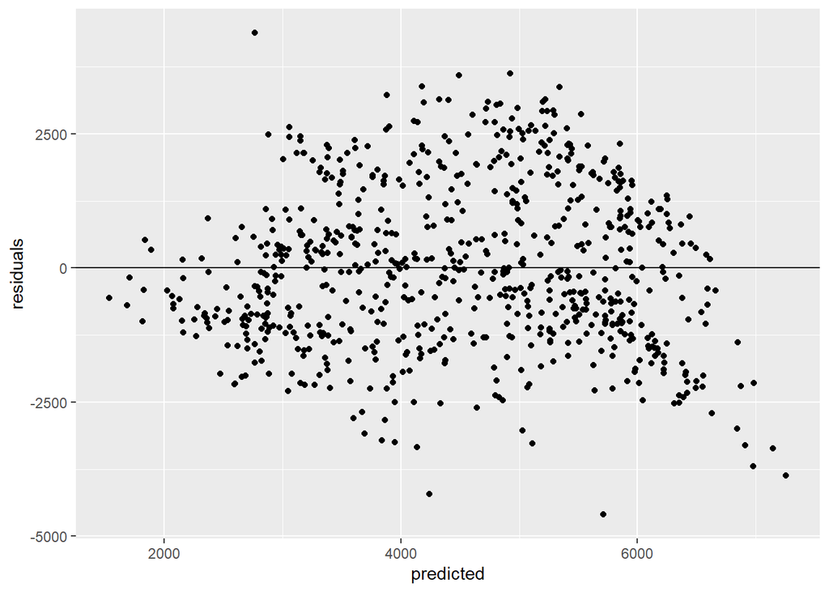

```r
modA = lm(riders_total ~ 1+temp_feel, data=bikes)

datA <- data.frame(
  residuals=modA$residuals,
  predicted=modA$fitted.values)

ggplot(datA, aes(x=predicted, y=residuals))+
  geom_point()+
  geom_hline(yintercept=0)
```

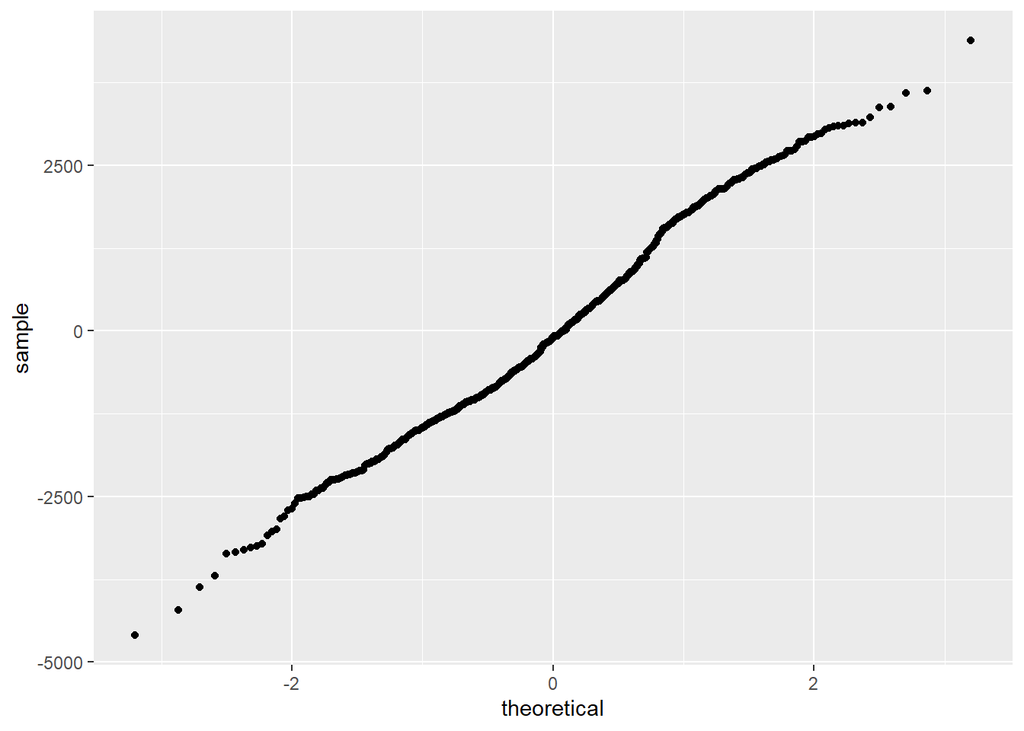

```r
ggplot(datA, aes(sample=residuals))+
  geom_qq()
```

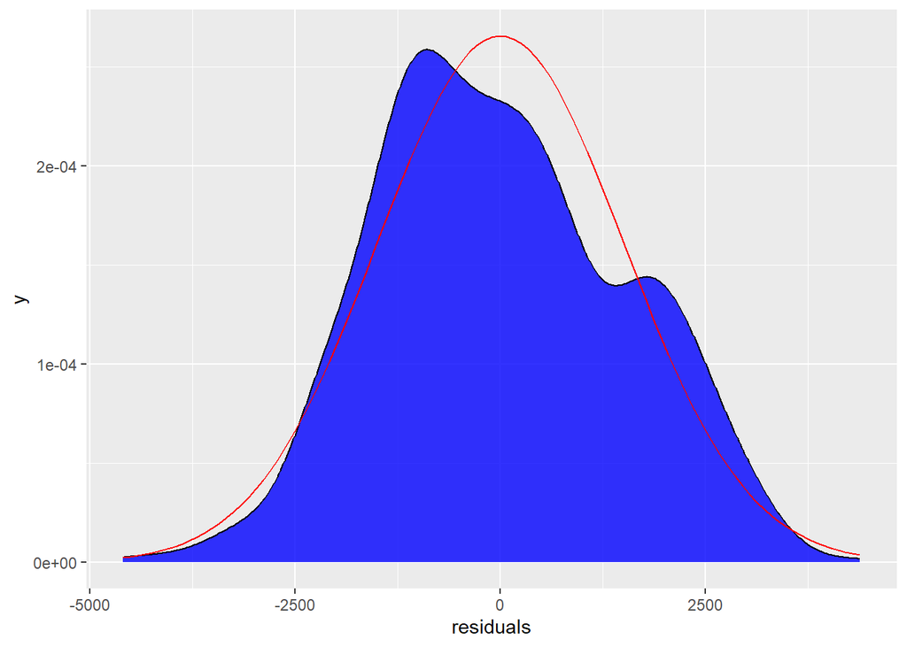

```r
ggplot(datA, aes(x=residuals)) +
  geom_density(fill="blue",alpha=.8)+
  stat_function(fun = dnorm, n = 101, args = list(mean = 0, sd = sd(datA$residuals)),color="red")
```

::: {.solution} Part a Assumptions - Independence: Unmet. The temperature from one day to the next is not independent. We expect similar temperatures from one day to the next. - Expected value of residuals: Met. Residuals appear balanced on residual plot, with the exception of the right tail. - Homoskedasticity: Unmet. Residuals have greater variance in the center, around x=4500, than in the beginning, around x=2000. - Normality of residuals: Met? Looks pretty normal :::

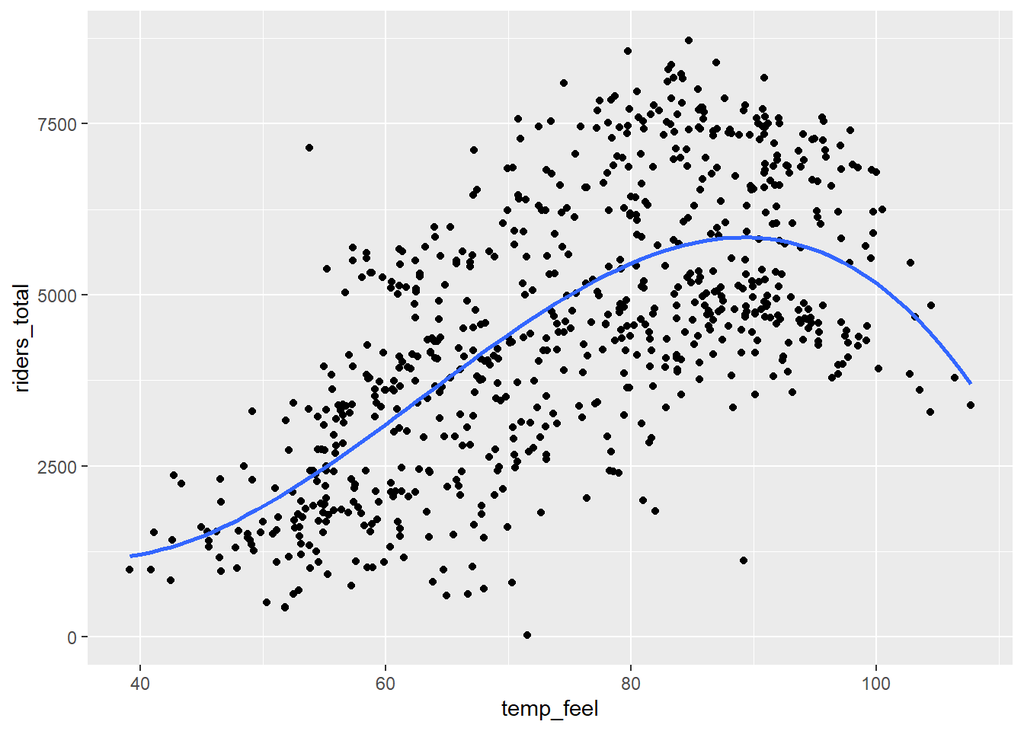

```r
ggplot(bikes, aes(x=temp_feel, y=riders_total))+
  geom_point()+
  geom_smooth(method="lm",formula=y~poly(x,3),se=FALSE)
```

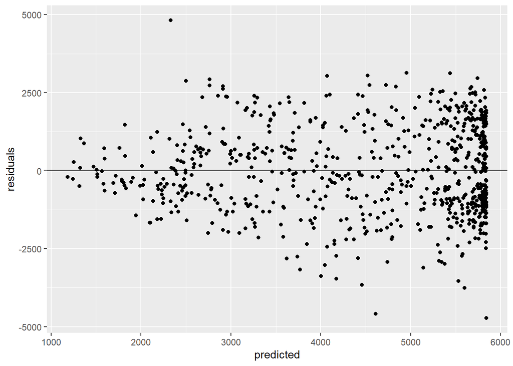

```r
modB = lm(riders_total ~ poly(temp_feel,3), data=bikes)

datB <- data.frame(
  residuals=modB$residuals,
  predicted=modB$fitted.values)

ggplot(datB, aes(x=predicted, y=residuals))+
  geom_point()+
  geom_hline(yintercept=0)
```

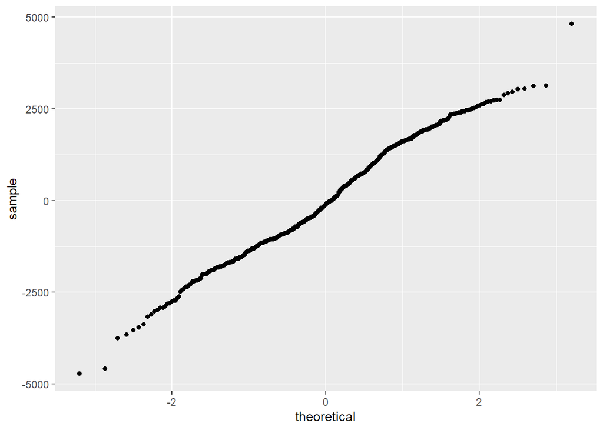

```r
ggplot(datB, aes(sample=residuals))+
  geom_qq()
```

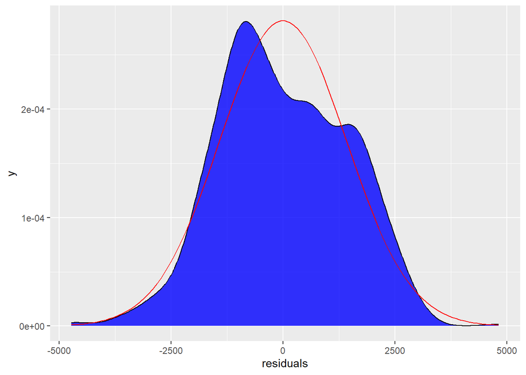

```r
ggplot(datB, aes(x=residuals)) +
  geom_density(fill="blue",alpha=.8)+
  stat_function(fun = dnorm, n = 101, args = list(mean = 0, sd = sd(datB$residuals)),color="red")
```

::: {.solution} Part b Assumptions - Independence: Unmet. The temperature from one day to the next is not independent. We expect similar temperatures from one day to the next. - Expected value of residuals: Met. Residuals appear balanced above and below residual plot. - Homoskedasticity: Met? Slight cone shape happening. - Normality of residuals: Met? Looks pretty normal :::

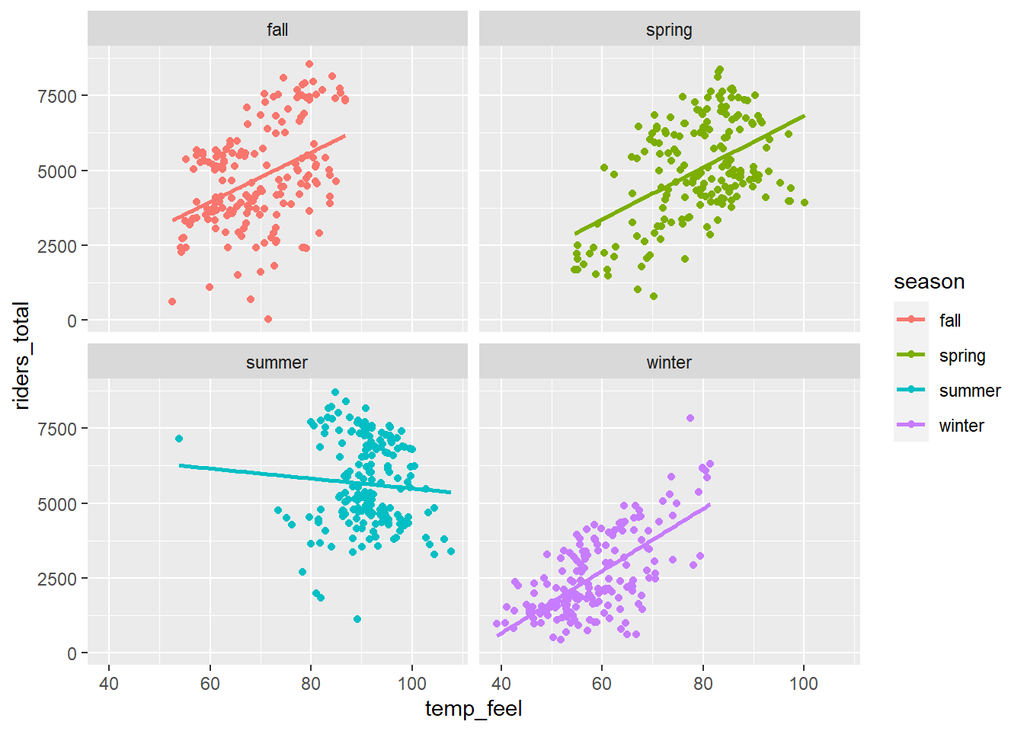

```r
ggplot(bikes, aes(x=temp_feel, y=riders_total, color=season))+
  geom_point()+
  geom_smooth(method='lm',se=FALSE)+
  facet_wrap(~season)
```

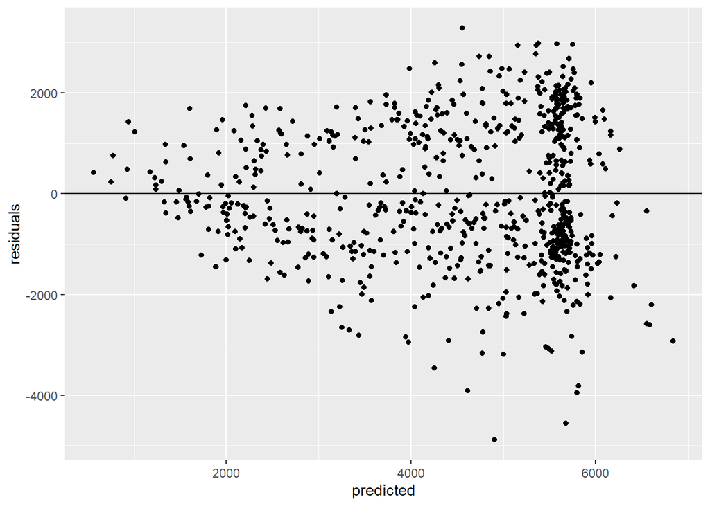

```r
modC = lm(riders_total ~ 1 + temp_feel + season + temp_feel:season, data=bikes)

datC <- data.frame(
  residuals=modC$residuals,
  predicted=modC$fitted.values)

ggplot(datC, aes(x=predicted, y=residuals))+
  geom_point()+
  geom_hline(yintercept=0)
```

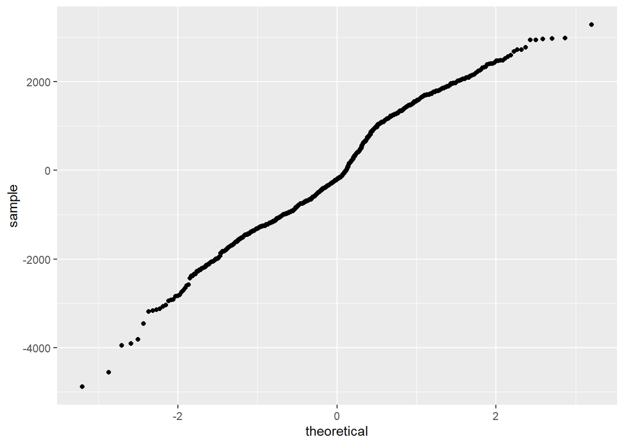

```r
ggplot(datC, aes(sample=residuals))+
  geom_qq()
```

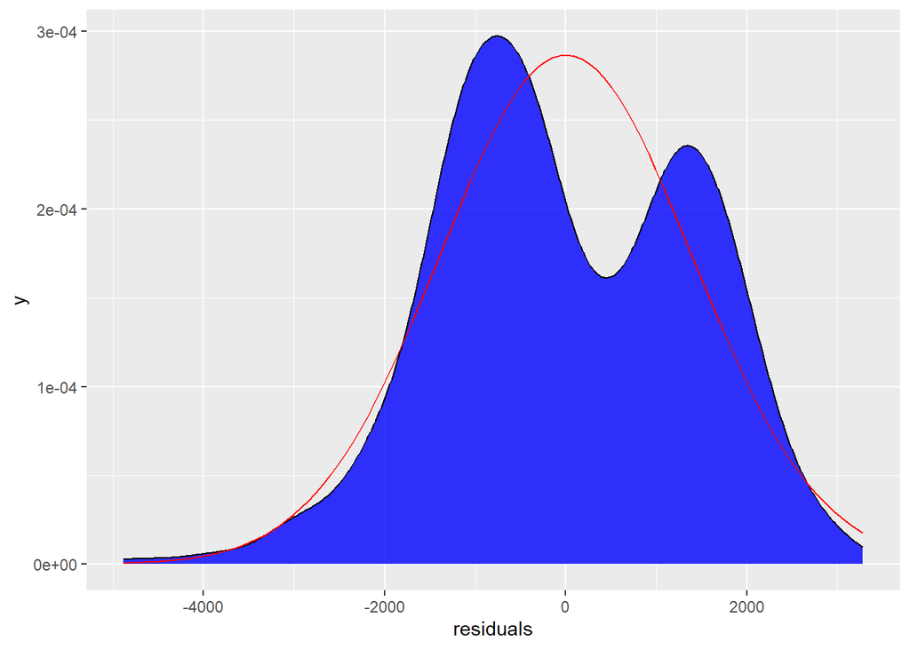

```r
#
ggplot(datC, aes(x=residuals)) +
  geom_density(fill="blue",alpha=.8)+
  stat_function(fun = dnorm, n = 101, args = list(mean = 0, sd = sd(datC$residuals)),color="red")
```

*Solution*. Part c Assumptions - Independence: Unmet. The temperature from one day to the next is not independent. We expect similar temperatures from one day to the next. - Expected value of residuals: Met? Residuals appear balanced above and below residual plot, but with some extra in the bottom right. - Homoskedasticity: Unmet. Cone shape happening. - Normality of residuals: Unmet. Big dip in the center.

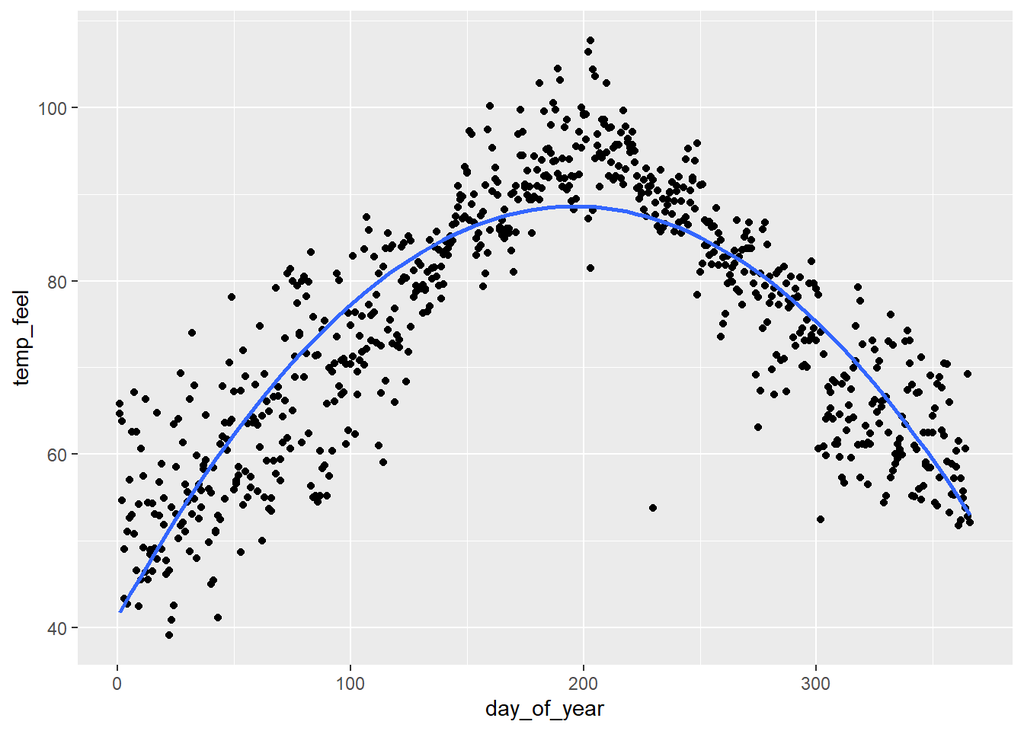

```r
ggplot(bikes, aes(x=day_of_year, y=temp_feel))+
  geom_point()+
  geom_smooth(method='lm',formula=y~poly(x,2),se=FALSE)
```

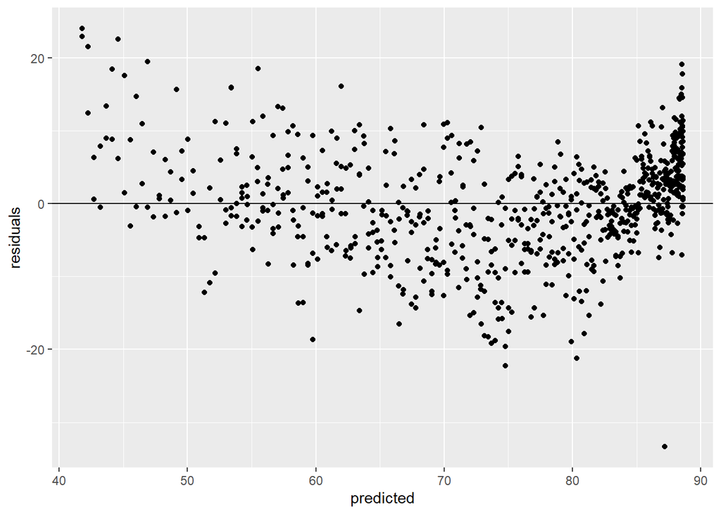

```r
modD = lm(temp_feel ~ poly(day_of_year,2), data=bikes)

datD <- data.frame(
  residuals=modD$residuals,
  predicted=modD$fitted.values)

ggplot(datD, aes(x=predicted, y=residuals))+
  geom_point()+
  geom_hline(yintercept=0)
```

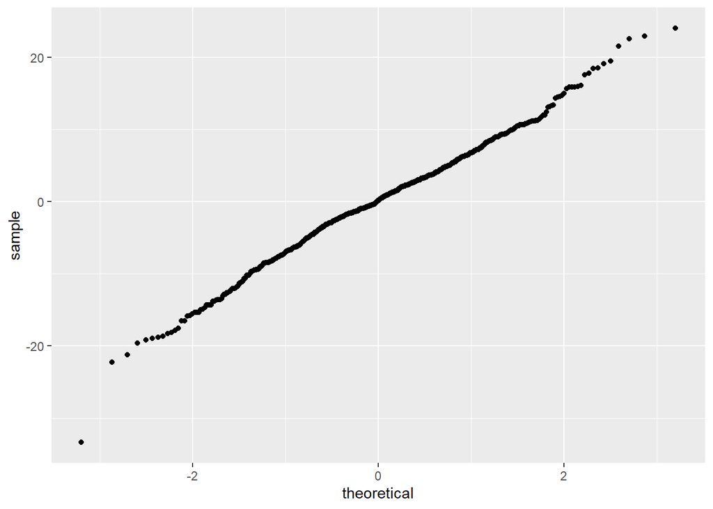

```r
ggplot(datD, aes(sample=residuals))+
  geom_qq()
```

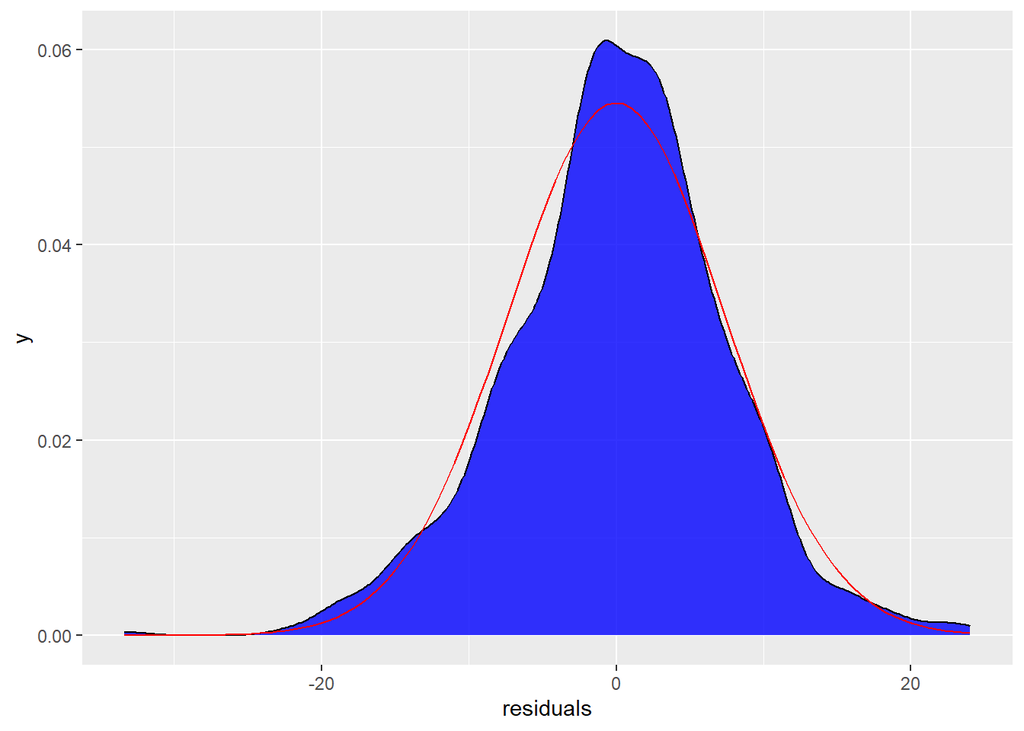

```r
ggplot(datD, aes(x=residuals)) +
  geom_density(fill="blue",alpha=.8)+
  stat_function(fun = dnorm, n = 101, args = list(mean = 0, sd = sd(datD$residuals)),color="red")
```

::: {.solution} Part d Assumptions - Independence: Unmet. The temperature from one day to the next is not independent. We expect similar temperatures from one day to the next. - Expected value of residuals: Unmet? There seem to be an even number of points above and below, but the residuals plot is curved down, not sure that falls into the next assumption though. - Homoskedasticity: Unmet. Banana shape happening. - Normality of residuals: Met. Looks quite normal. :::

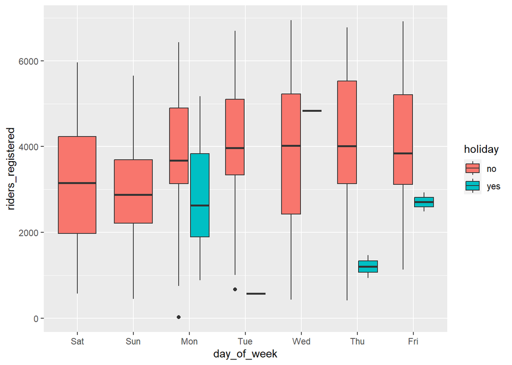

```r
ggplot(bikes, aes(x=day_of_week, y=riders_registered, fill=holiday))+
  geom_boxplot()
```

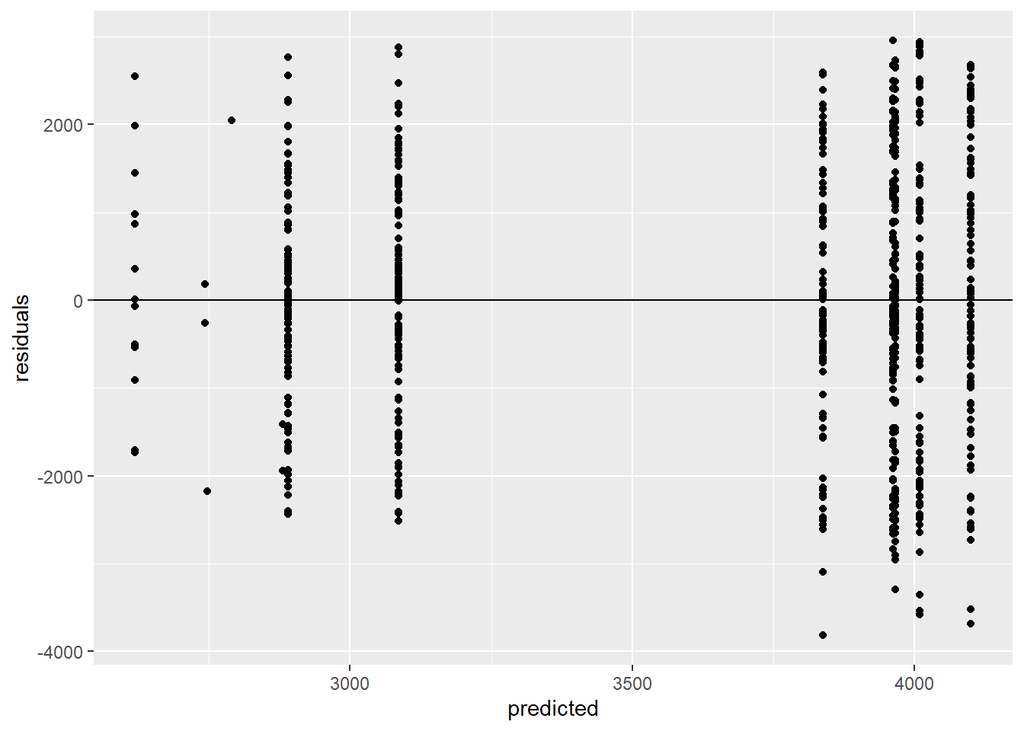

```r
modE = lm(riders_registered ~ 1 + day_of_week + holiday, data=bikes)

datE <- data.frame(
  residuals=modE$residuals,
  predicted=modE$fitted.values)

ggplot(datE, aes(x=predicted, y=residuals))+
  geom_point()+
  geom_hline(yintercept=0)
```